# Generalised additive models

Modelling curves with smooth terms

Dr Massimiliano Canzi

# Generalised additive models

`Did you know:` humpback whales produce a varied series of sounds for 7 to 30 minutes and then repeat the same series with considerable precision. Payne and McVay called each repeated series a song.

*Source: Payne & McVay (1971), Science*

## Where we are

So far, every model in this course has been linear in its predictors. Many linguistic data are curves: formant trajectories, pitch contours, tongue contours, pupil size over a trial, looks to a target over time.

This lecture and the next one follow Márton Sóskuthy’s GAMM workshop (Analysing Curves, University of Manchester, 2018) and his written tutorial (Sóskuthy, 2017), with simulated data and `ggplot2` figures.

## Today

1. Curves
2. Smooth terms
3. Fitting GAMs with `{mgcv}`
4. Comparing curves

## The data

`price_f2` from {simling}: F2 of the PRICE vowel at 11 points (0% to 100% of the vowel), 10 tokens from each of 20 speakers, 10 with English and 10 with Italian as their L1.

```r
price <- price_f2
price
```

```
# A tibble: 2,200 × 6
  speaker l1      traj  duration  time    f2
  <fct>   <fct>   <fct>    <dbl> <dbl> <dbl>
1 S01     English S01.1      252     0  1199
2 S01     English S01.1      252    10  1232
3 S01     English S01.1      252    20  1174
4 S01     English S01.1      252    30  1194
# ℹ 2,196 more rows
```

`?price_f2` gives the true model. The glide from [a] to [ɪ] is smaller and earlier for the Italian speakers, short vowels undershoot the glide target, and neighbouring measurements in a token are correlated.

## The trajectories

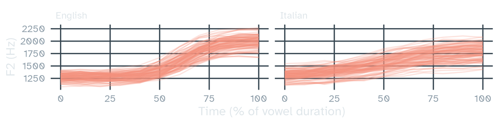

```r
ggplot(price, aes(x = time, y = f2, group = traj)) +
  geom_line(colour = kingfisher, alpha = 0.25) +
  facet_wrap(~ l1) +
  labs(x = "Time (% of vowel duration)", y = "F2 (Hz)")
```

Each line is one token. The research question is whether the two groups produce different F2 trajectories.

# Curves

`Did you know:` humpback whale song is built in layers. Single sounds (units) form phrases, a repeated phrase forms a theme, and a fixed sequence of themes forms the song.

*Source: Payne & McVay (1971), Science*

## A straight line

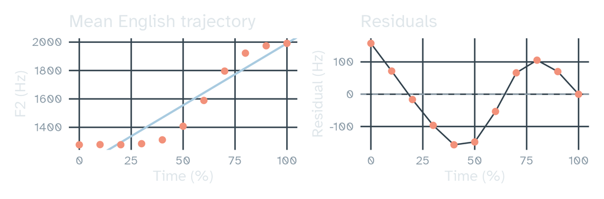

The line misses the shape, and the residuals follow a pattern: neighbouring residuals are similar. This is autocorrelation, and it makes standard errors unreliable.

## Polynomials

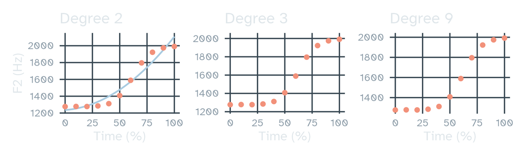

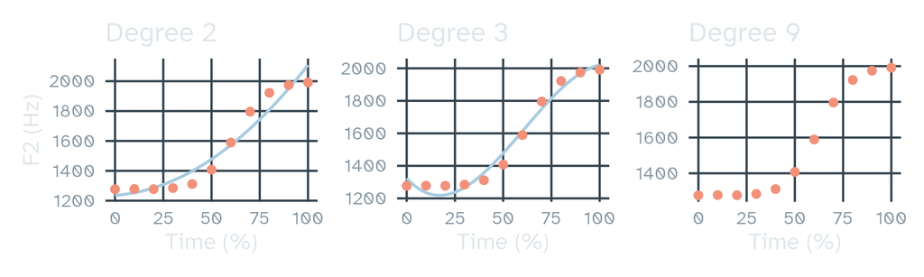

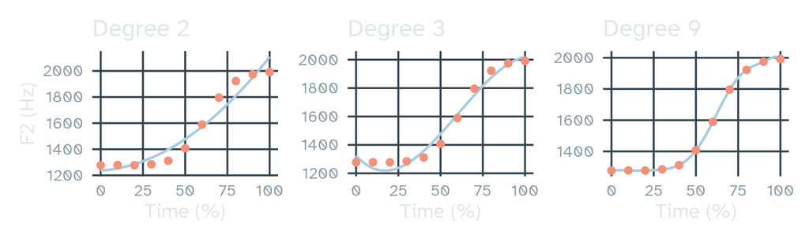

- A quadratic or cubic term underfits: it cannot follow the flat start and the late rise
- A high-degree polynomial overfits: it bends to follow the noise

Nothing in the data says which degree to choose.

# Smooth terms

`Did you know:` humpback whales off eastern Australia replaced their song within two years. A few singers from the west coast had brought a new song, and by 1998 only the new song was heard.

*Source: Noad et al. (2000), Nature*

## Smooth terms

A generalised additive model can contain smooth terms next to the usual parametric terms:

y = α + β₁ · x₁ + f(x₂) + e

`f(x₂)` is a smooth function of `x₂` whose shape is estimated from the data. It is built as a sum of simpler functions, the basis functions, much as a polynomial is a sum of powers of `x`. A smoothing penalty keeps it from following the noise.

## Basis functions

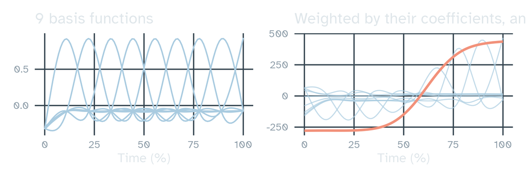

Each basis function is multiplied by a coefficient; the sum (salmon), plus the intercept, is the fitted curve. `bs = "cr"` asks for cubic regression splines, and `k = 10` gives 10 basis functions, one of which is absorbed by the intercept.

## How wiggly?

- `k` sets the maximum wiggliness: how many basis functions the smooth may use
- The smoothing parameter sets the actual wiggliness: the larger it is, the more wiggliness is penalised
- `{mgcv}` estimates the smoothing parameter from the data, so the strategy is to set `k` high enough and let the penalty do the rest
- The effective degrees of freedom (edf) describe the result: an edf of 1 is a straight line, and higher values mean more wiggly curves

## The smoothing parameter

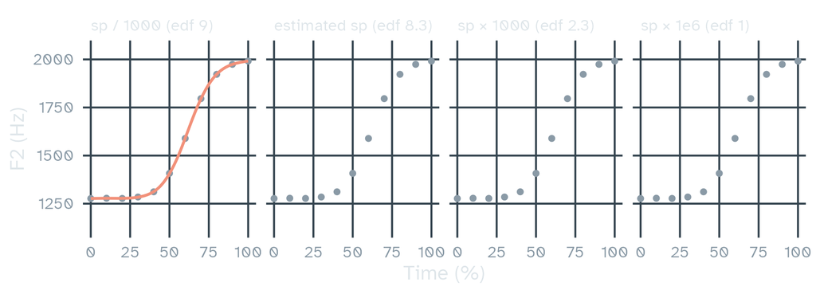

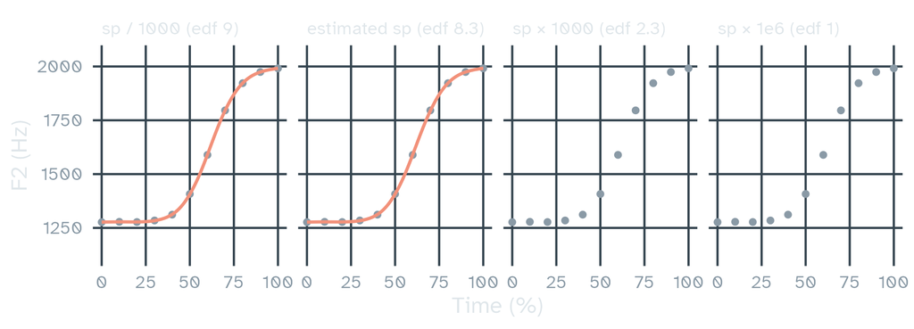

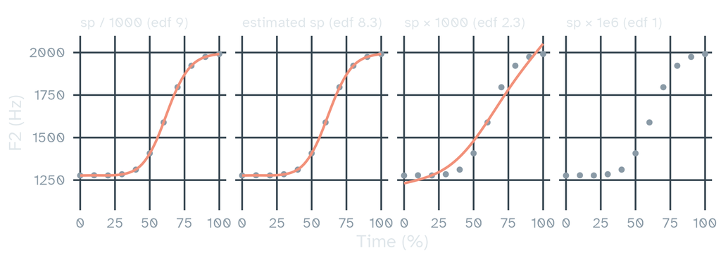

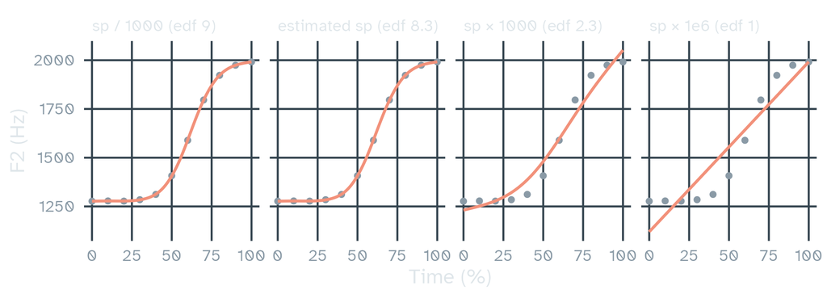

The same 10 basis functions with four smoothing parameters. A large penalty pushes the smooth toward a straight line.

# Fitting GAMs with `{mgcv}`

`Did you know:` over 11 years, 11 song types spread across the humpback whale populations of the South Pacific, usually starting off eastern Australia and reaching French Polynesia within about two years.

*Source: Garland et al. (2011), Current Biology*

## `gam()` and `bam()`

- `{mgcv}` (Wood, 2017) fits GAMs with `gam()`, and with `bam()`, which is much faster on big data sets such as curves
- `s(time)` is a smooth over time; `s(time, by = l1)` fits a separate smooth for each group
- Smooths in a `by` model are centred on zero, so the group difference in height needs its own parametric term, `l1`
- `method = "ML"` is needed to compare models that differ in their fixed effects; the default of `bam()` is `"fREML"`

## A first GAM

```r
m1 <- bam(f2 ~ l1 + s(time, by = l1, k = 10), data = price, method = "ML")
round(summary(m1)$p.table, 2)
```

```
            Estimate Std. Error t value Pr(>|t|)
(Intercept)  1555.40       3.38  460.62     0.00
l1Italian      -4.78       4.78   -1.00     0.32
```

```r
round(summary(m1)$s.table, 2)
```

```
                   edf Ref.df      F p-value
s(time):l1English 7.54   8.48 888.25       0
s(time):l1Italian 4.92   6.01 424.13       0
```

## Reading the summary

- The parametric table works as in `lm()`: the intercept is the mean F2 of the English trajectories, and `l1Italian` is how much higher or lower the Italian trajectories are on average
- The smooth table has one row per smooth: `edf` close to 9 means a very wiggly curve, close to 1 a straight line

The F test asks whether a smooth is flat, so two identical curves would both come out significant. Testing whether two smooths differ needs a different model, later in this lecture.

## Plotting with `{tidygam}`

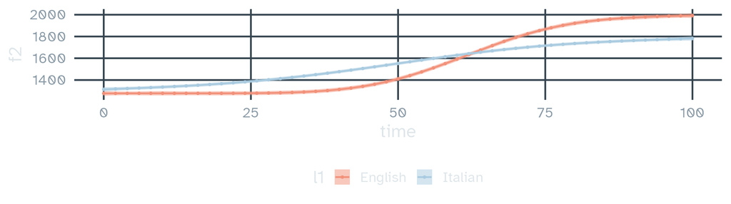

```r
m1_pred <- predict_gam(m1, series = "time", length_out = 50)
plot(m1_pred, series = "time", comparison = "l1")
```

`predict_gam()` returns a tibble of predictions with standard errors and 95% confidence intervals; its `plot()` method draws them with `ggplot2`.

## Your own plot

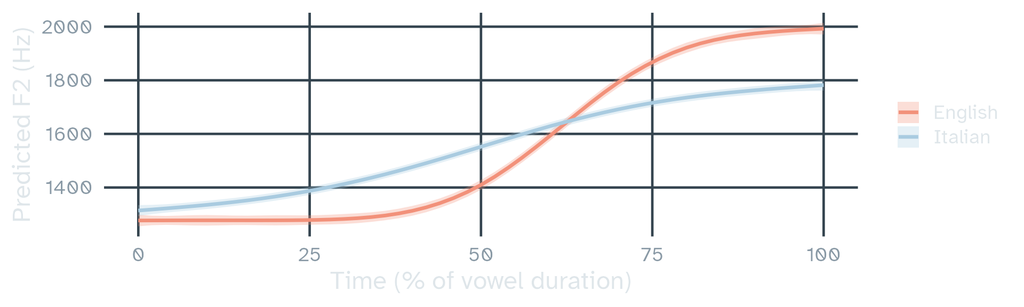

```r
ggplot(m1_pred, aes(x = time, y = f2, colour = l1, fill = l1)) +
  geom_ribbon(aes(ymin = lower_ci, ymax = upper_ci), alpha = 0.3, colour = NA) +
  geom_line(linewidth = 1.2) +
  labs(x = "Time (% of vowel duration)", y = "Predicted F2 (Hz)", colour = NULL, fill = NULL) +
  theme(legend.position = "right")
```

`m1_pred` is an ordinary tibble with the predictor values, the predicted `f2`, its standard error `se`, and the limits `lower_ci` and `upper_ci`.

## Is `k` high enough?

```r
k.check(m1)
```

```
                  k'      edf   k-index p-value
s(time):l1English  9 7.540370 0.5732537       0
s(time):l1Italian  9 4.924248 0.5732537       0
```

- `k'` is the number of basis functions available; `edf` is how many the smooth used
- A k-index below 1 with a small p-value suggests there is pattern left in the residuals that more basis functions could capture

To be sure, raise `k` (for example to 15) and refit. If the curves and the edf barely change, `k` was high enough.

## Choosing `k`

- Start from what you expect: a formant trajectory over 11 points rarely needs more than 10 basis functions; a pitch contour over a whole sentence may need 20 or more
- Look at the fitted curves against the data, compare `edf` with `k'`, and use `k.check()`

In Sóskuthy’s (2018) workshop example, `gam.check()` flagged smooths whose wiggliness simulations showed to be fine. Use these checks as guides, together with the plots.

# Comparing curves

`Did you know:` in each humpback whale population, only males sing, and all of them sing the current version of the song, which keeps changing over the years.

*Source: Garland et al. (2011), Current Biology*

## Reference and difference smooths

To test whether two curves differ, the model needs a term for the difference. With an ordered factor in `by`, `s(time)` becomes the reference smooth for the first level, and `s(time, by = l1_o)` the difference between the other level and the reference.

```r
price <- mutate(price, l1_o = as.ordered(l1))
contrasts(price$l1_o) <- "contr.treatment"
m2 <- bam(f2 ~ l1_o + s(time, k = 10) + s(time, by = l1_o, k = 10),
          data = price, method = "ML")
```

## The difference smooth

```r
round(summary(m2)$p.table, 2)
```

```
            Estimate Std. Error t value Pr(>|t|)
(Intercept)  1555.40       3.38  460.36     0.00
l1_oItalian    -4.78       4.78   -1.00     0.32
```

```r
round(summary(m2)$s.table, 2)
```

```
                     edf Ref.df      F p-value
s(time)             7.75   8.51 883.90       0
s(time):l1_oItalian 6.59   7.65 108.44       0
```

- `s(time)` is the English trajectory, and `s(time):l1_oItalian` is the difference smooth: the Italian trajectory minus the English one, apart from the overall difference in height captured by `l1_oItalian`
- `m1` and `m2` fit the same curves in two parametrisations

## Plotting the difference

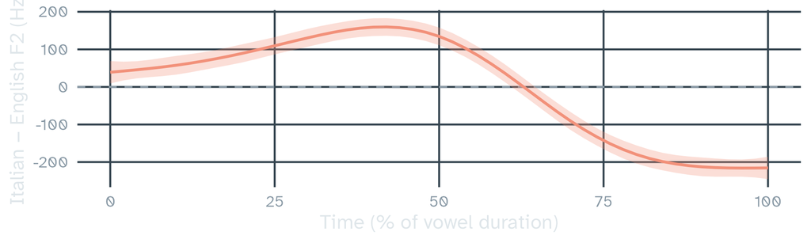

```r
m2_diff <- get_difference(m2, "time", list(l1_o = c("Italian", "English")), length_out = 50)
ggplot(m2_diff, aes(x = time, y = diff)) +
  geom_hline(yintercept = 0, colour = muted, linetype = "dashed") +
  geom_ribbon(aes(ymin = lower_ci, ymax = upper_ci), fill = kingfisher, alpha = 0.3) +
  geom_line(colour = kingfisher, linewidth = 1.2) +
  labs(x = "Time (% of vowel duration)", y = "Italian − English F2 (Hz)")
```

Where the 95% confidence interval excludes zero, the curves differ. `plot(m2_diff)` shades those stretches automatically.

## Model comparison

```r
m2_null <- bam(f2 ~ s(time, k = 10), data = price, method = "ML")
itsadug::compareML(m2_null, m2)
```

```
m2_null: f2 ~ s(time, k = 10)

m2: f2 ~ l1_o + s(time, k = 10) + s(time, by = l1_o, k = 10)

Chi-square test of ML scores
-----
    Model    Score Edf Difference    Df  p.value Sig.
1 m2_null 13869.68   3
2      m2 13529.22   6    340.453 3.000  < 2e-16  ***

AIC difference: 699.89, model m2 has lower AIC.
```

The null model drops both the height difference and the difference smooth. Both models are fitted with `method = "ML"`.

## The binary smooth

```r
price <- mutate(price, is_italian = as.numeric(l1 == "Italian"))
m2_bin <- bam(f2 ~ s(time, k = 10) + s(time, by = is_italian, k = 10),
              data = price, method = "ML")
```

- In a binary smooth, the `by` variable is numeric (0 or 1). The smooth is therefore not centred, and a single term covers both the difference in height and the difference in shape
- Its p-value tests both differences at once, which is often the question of interest

## Which test to report?

Sóskuthy’s (2018) recommendations:

- Use the model summary only as a rough guide
- Report the significance from a model comparison
- Use prediction plots and the difference smooth for the qualitative discussion: where and how the curves differ

He calls the binary smooth probably ideal when, as here, a single difference between two curves is the question.

## The catch

These models treat all 2,200 measurements as independent, although 11 come from each token and 110 from each speaker.

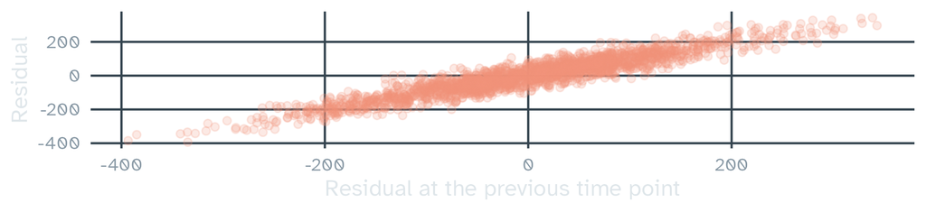

```r
tibble(res = residuals(m2), lagged = lag(res), time = price$time) |>
  filter(time > 0) |>
  ggplot(aes(x = lagged, y = res)) +
  geom_point(colour = kingfisher, alpha = 0.2) +
  labs(x = "Residual at the previous time point", y = "Residual")
```

Neighbouring residuals are correlated, so the confidence intervals above are too narrow. Lecture 3 deals with this.

## Summary

- Polynomials underfit or overfit curves, and leave the choice of degree to the analyst
- A smooth term is a weighted sum of basis functions; `k` sets the maximum wiggliness and the smoothing penalty the actual wiggliness
- The smooth table tests whether each smooth is flat; an ordered factor in `by` gives a reference smooth and a difference smooth; plot the difference with its confidence interval
- Report the significance from a model comparison; describe the curves with prediction plots and the difference smooth
- Models without random effects or an error model are overconfident with curve data

## References

- Coretta, S. (2024). *tidygam: Tidy prediction and plotting of generalised additive models* (R package version 1.0.0). https://github.com/stefanocoretta/tidygam
- Sóskuthy, M. (2017). Generalised additive mixed models for dynamic analysis in linguistics: A practical introduction. *arXiv*, 1703.05339. https://arxiv.org/abs/1703.05339
- Sóskuthy, M. (2018). *Introducing generalised additive models* and *Becoming a GAM(M) warrior* [Workshop slides]. Analysing Curves, University of Manchester, 29 May 2018.
- Sóskuthy, M. (2021). Evaluating generalised additive mixed modelling strategies for dynamic speech analysis. *Journal of Phonetics*, 84, 101017. https://doi.org/10.1016/j.wocn.2020.101017
- van Rij, J., Wieling, M., Baayen, R. H., & van Rijn, H. (2025). *itsadug: Interpreting time series and autocorrelated data using GAMMs* (R package). https://CRAN.R-project.org/package=itsadug
- Wood, S. N. (2017). *Generalized additive models: An introduction with R* (2nd ed.). CRC Press. https://doi.org/10.1201/9781315370279

## Sources of the animal facts

- Garland, E. C., Goldizen, A. W., Rekdahl, M. L., Constantine, R., Garrigue, C., Hauser, N. D., Poole, M. M., Robbins, J., & Noad, M. J. (2011). Dynamic horizontal cultural transmission of humpback whale song at the ocean basin scale. *Current Biology*, 21(8), 687–691. https://doi.org/10.1016/j.cub.2011.03.019
- Noad, M. J., Cato, D. H., Bryden, M. M., Jenner, M.-N., & Jenner, K. C. S. (2000). Cultural revolution in whale songs. *Nature*, 408, 537. https://doi.org/10.1038/35046199
- Payne, R. S., & McVay, S. (1971). Songs of humpback whales. *Science*, 173(3997), 585–597. https://doi.org/10.1126/science.173.3997.585

## Slides and code

[figure not shown]

These slides

mcanzi.de/advanced_statistics/02_gams.html

Code and all lectures

github.com/mcanzi/advanced_statistics